# A Quick Tour of multiROC

Jingye Wang, Runmin Wei, Wei Jia

2018-01-09

# 1 Introduction

The receiver operating characteristic (ROC) is an extensively utilized method for comparing binary classifiers in various areas. However, many real-world problems are designed to multiple classes (e.g., tumor, node, and metastasis staging system of cancer), which require an evaluation strategy to assess multiclass classifiers. This package aims to fill the gap by enabling the calculation of multiclass ROC-AUC with confidence intervals and the generation of publication-quality figures of multiclass ROC curves.

# 2 Data Preparation

```r
library(multiROC)
data(test_data)
head(test_data)
```

```
#>   G1_true G2_true G3_true G1_pred_m1 G2_pred_m1 G3_pred_m1 G1_pred_m2
#> 1       1       0       0  0.8566867  0.1169520 0.02636133  0.4371601
#> 2       1       0       0  0.8011788  0.1505448 0.04827643  0.3075236
#> 3       1       0       0  0.8473608  0.1229815 0.02965766  0.3046363
#> 4       1       0       0  0.8157730  0.1422322 0.04199482  0.2378494
#> 5       1       0       0  0.8069553  0.1472971 0.04574766  0.4067347
#> 6       1       0       0  0.6894488  0.2033285 0.10722271  0.1063048
#>   G2_pred_m2 G3_pred_m2
#> 1  0.1443851 0.41845482
#> 2  0.5930025 0.09947397
#> 3  0.4101367 0.28522698
#> 4  0.5566147 0.20553591
#> 5  0.2355822 0.35768312
#> 6  0.4800507 0.41364450
```

This example dataset contains two classifiers (m1, m2), and three groups (G1, G2, G3).

# 3 MultiROC in a nutshell

## 3.1 multi_roc function

```r
res <- multi_roc(test_data, force_diag=T)
```

The function **multi_roc** is the core function for calculating multiclass ROC-AUC.

Arguments of **multi_roc**:

- **true_pred** is the dataset contains both of true labels and corresponding predicted scores. True labels (0 - Negative, 1 - Positive) columns should be named as XX_true (e.g., S1_true, S2_true) and predictive scores (continuous) columns should be named as XX_pred_YY (e.g., S1_pred_SVM, S2_pred_RF). Predictive scores can be probabilities among [0, 1] or other continuous values. For each classifier, the number of columns should be equal to the number of groups of true labels.
- If **force_diag** equals TRUE, true positive rate (TPR) and false positive rate (FPR) will be forced to across (0, 0) and (1, 1).

Outputs of **multi_roc**:

- **Specificity** contains a list of specificities for each group of different classifiers.
- **Sensitivity** contains a list of sensitivities for each group of different classifiers.
- **AUC** contains a list of AUC for each group of different classifiers. Micro-average ROC/AUC was calculated by stacking all groups together, thus converting the multi-class classification into binary classification. Macro-average ROC/AUC was calculated by averaging all groups results (one vs rest) and linear interpolation was used between points of ROC.
- **Methods** shows names of different classifiers.
- **Groups** shows names of different groups.

## 3.2 Confidence Intervals

### 3.2.1 List of AUC results

```r
unlist(res$AUC)
```

```
#>     m1.G1     m1.G2     m1.G3  m1.macro  m1.micro     m2.G1     m2.G2
#> 0.7233607 0.5276190 0.9751462 0.7420609 0.8824221 0.3237705 0.3723810
#>     m2.G3  m2.macro  m2.micro
#> 0.4020468 0.3665670 0.4174394
```

This list shows the following AUC information:

1. AUC of G1 v.s. the rest in the classifier m1;
2. AUC of G2 v.s. the rest in the classifier m1;
3. AUC of G3 v.s. the rest in the classifier m1;
4. AUC of Macro in the classifier m1;
5. AUC of Micro in the classifier m1;
6. AUC of G1 v.s. the rest in the classifier m2;
7. AUC of G2 v.s. the rest in the classifier m2;
8. AUC of G3 v.s. the rest in the classifier m2;
9. AUC of Macro in the classifier m2;
10. AUC of Micro in the classifier m2.

### 3.2.2 Bootstrap

```r
multi_roc_auc <- function(true_pred_data, idx) {
  results <- multi_roc(true_pred_data[idx, ])$AUC
  results <- unlist(results)
  return(results)
}

res_boot <- boot::boot(data=test_data, statistic=multi_roc_auc, R=1000)
res_boot_ci <- boot::boot.ci(res_boot, type='bca', index=4)
res_boot_ci
```

```
#> BOOTSTRAP CONFIDENCE INTERVAL CALCULATIONS
#> Based on 1000 bootstrap replicates
#>
#> CALL :
#> boot::boot.ci(boot.out = res_boot, type = "bca", index = 4)
#>
#> Intervals :
#> Level       BCa
#> 95%   ( 0.6520,  0.8311 )
#> Calculations and Intervals on Original Scale
```

- **R** is the number of bootstrap replicates.
- **index** is the position of the list of AUC results in 3.2.1.

Here, we set index = 4 to calculate 95% CI of AUC of Macro in the classifier m1 based on 1000 bootstrap replicates as an example.

# 4 Plots

## 4.1 change the format of results to a ggplot2 friendly format.

```r
n_method <- length(unique(res$Methods))
n_group <- length(unique(res$Groups))
res_df <- data.frame(Specificity= numeric(0), Sensitivity= numeric(0), Group = character(0), AUC = numeric(0), Method = character(0))
for (i in 1:n_method) {
      for (j in 1:n_group) {
        temp_data_1 <- data.frame(Specificity=res$Specificity[[i]][j],
                                  Sensitivity=res$Sensitivity[[i]][j],
                                  Group=unique(res$Groups)[j],
                                  AUC=res$AUC[[i]][j],
                                  Method = unique(res$Methods)[i])
        colnames(temp_data_1) <- c("Specificity", "Sensitivity", "Group", "AUC", "Method")
        res_df <- rbind(res_df, temp_data_1)

      }
      temp_data_2 <- data.frame(Specificity=res$Specificity[[i]][n_group+1],
                                Sensitivity=res$Sensitivity[[i]][n_group+1],
                                Group= "Macro",
                                AUC=res$AUC[[i]][n_group+1],
                                Method = unique(res$Methods)[i])
      temp_data_3 <- data.frame(Specificity=res$Specificity[[i]][n_group+2],
                                Sensitivity=res$Sensitivity[[i]][n_group+2],
                                Group= "Micro",
                                AUC=res$AUC[[i]][n_group+2],
                                Method = unique(res$Methods)[i])
      colnames(temp_data_2) <- c("Specificity", "Sensitivity", "Group", "AUC", "Method")
      colnames(temp_data_3) <- c("Specificity", "Sensitivity", "Group", "AUC", "Method")
      res_df <- rbind(res_df, temp_data_2)
      res_df <- rbind(res_df, temp_data_3)
    }
```

## 4.2 Plot

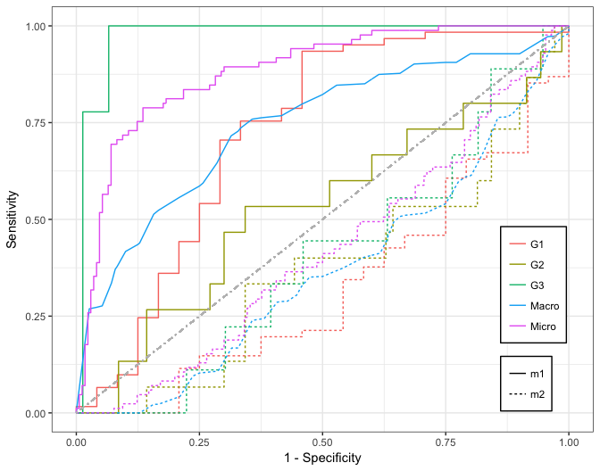

```r
ggplot2::ggplot(res_df, ggplot2::aes(x = 1-Specificity, y=Sensitivity)) + ggplot2::geom_path(ggplot2::aes(color = Group, linetype=Method)) + ggplot2::geom_segment(ggplot2::aes(x = 0, y = 0, xend = 1, yend = 1), colour='grey', linetype = 'dotdash') + ggplot2::theme_bw() + ggplot2::theme(plot.title = ggplot2::element_text(hjust = 0.5), legend.justification=c(1, 0), legend.position=c(.95, .05), legend.title=ggplot2::element_blank(), legend.background = ggplot2::element_rect(fill=NULL, size=0.5, linetype="solid", colour ="black"))
```